# Reproducible Research - PA1

Antonela Tomić

Sunday, September 14, 2014

**Loading and preprocessing the data**  
1. Load the data (i.e. read.csv())

```r
library("stringr")
library("knitr")
activity <- read.csv("activity.csv", header = TRUE, sep = ",", quote = "\"", dec = ".", fill = TRUE, comment.char = "")
```

2. Process/transform the data (if necessary) into a format suitable for your analysis

```r
maketimeformat <- function (x) {
    y <- ""
    if (nchar(x) == 1) {
        y <- str_c("00:0",x, sep = "")
        }
    if (nchar(x) == 2) {
        y <- str_c("00:",x, sep = "")
        }
    if (nchar(x) == 3) {
        y <- str_c("0",substr(x,1,1), ":", substr(x,2,3), sep = "")
        }
    if (nchar(x) == 4) {
        y <- str_c(substr(x,1,2), ":", substr(x,3,4), sep = "")
        }
    x <- y
}
```

**What is mean total number of steps taken per day?**  
*For this part of the assignment, you can ignore the missing values in the dataset.*  
1. Make a histogram of the total number of steps taken each day

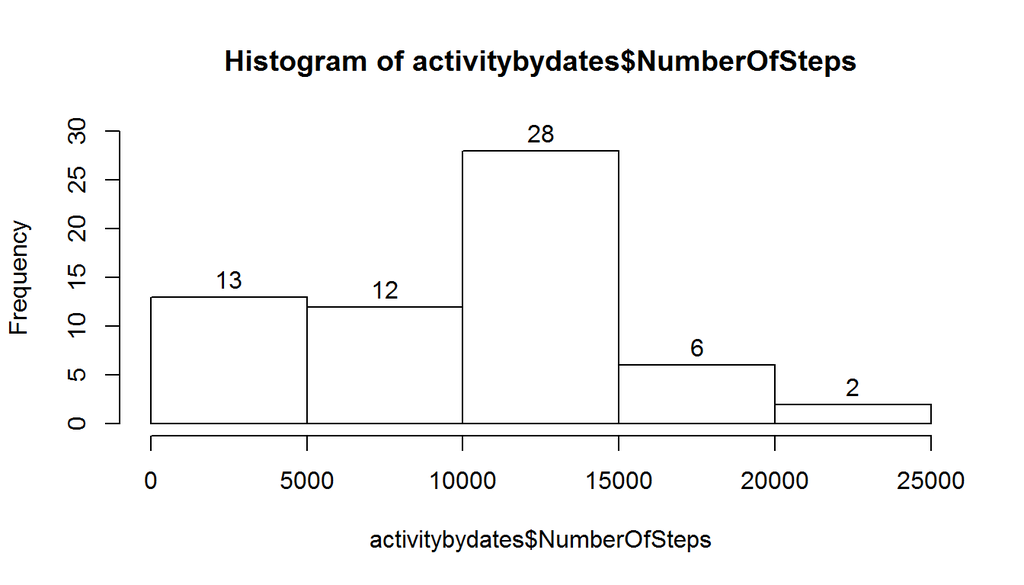

```r
activitybydates <- aggregate(activity$steps, by=list(activity$date), FUN=sum, na.rm=TRUE)
names(activitybydates) <- c("Date", "NumberOfSteps")
hist(activitybydates$NumberOfSteps, labels = TRUE, ylim = c(0, 30))
```

2. Calculate and report the mean and median total number of steps taken per day

```r
meansteps <- mean(activitybydates$NumberOfSteps)
msg1 <- cat("Mean number of steps per day is: ", meansteps)
```

```
## Mean number of steps per day is:  9354
```

```r
mediansteps <- median(activitybydates$NumberOfSteps)
msg2 <- cat("Median number of steps per day is: ", mediansteps)
```

```
## Median number of steps per day is:  10395
```

**What is the average daily activity pattern?**  
1. Make a time series plot (i.e. type = “l”) of the 5-minute interval (x-axis) and the average number of steps taken, averaged across all days (y-axis)

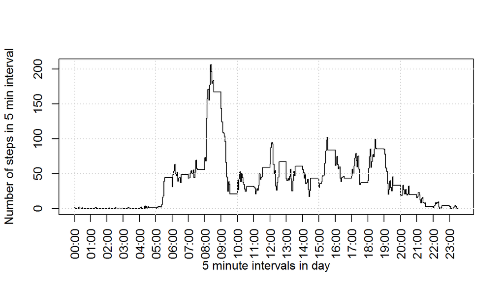

```r
activitybyintervals <- aggregate(activity$steps, by=list(activity$interval), FUN=mean, na.rm=TRUE)
names(activitybyintervals) <- c("Interval", "NumberOfSteps")
IntervalsLabels <- rep("00:00", 288)
for (i in 1:nrow(activitybyintervals)) {
    IntervalsLabels[i] <- maketimeformat(as.character(activitybyintervals$Interval[i]))
}
plot(activitybyintervals$Interval, activitybyintervals$NumberOfSteps, type="s", xlab = "5 minute intervals in day", ylab = "Number of steps in 5 min interval", labels = FALSE)
axis(side=2, labels=TRUE)
axis(side=1, at=activitybyintervals$Interval[seq(1, length(activitybyintervals$Interval),12)], labels=IntervalsLabels[seq(1, length(IntervalsLabels),12)], las=2)
grid(nx = NULL, ny = NULL, col = "lightgray", lty = "dotted")
```

2. Which 5-minute interval, on average across all the days in the dataset, contains the maximum number of steps?

```r
maxsteps <- activitybyintervals[activitybyintervals$NumberOfSteps==max(activitybyintervals$NumberOfSteps),]
maxstepsstart <- maketimeformat(maxsteps$Interval)
maxstepsend <- maketimeformat(maxsteps$Interval + 5)
cat("Maximum number of steps on average is between", maxstepsstart, "and", maxstepsend)
```

```
## Maximum number of steps on average is between 08:35 and 08:40
```

**Imputing missing values**  
*Note that there are a number of days/intervals where there are missing values (coded as NA). The presence of missing days may introduce bias into some calculations or summaries of the data.*  
1. Calculate and report the total number of missing values in the dataset (i.e. the total number of rows with NAs)

```r
summ <- summary(activity)
cat("Number of missing values is\n",summ[7])
```

```
## Number of missing values is
##  NA's   :2304
```

2. Devise a strategy for filling in all of the missing values in the dataset. The strategy does not need to be sophisticated. For example, you could use the mean/median for that day, or the mean for that 5-minute interval, etc.
3. Create a new dataset that is equal to the original dataset but with the missing data filled in.

```r
activityfill <- activity
activityfillna <- is.na(activityfill$steps)
nna <- length(activityfill$steps[activityfillna])
for (i in 1:nrow(activityfill)) {
    if (is.na(activityfill$steps[i])) {
        activityfill$steps[i] <- activitybyintervals$NumberOfSteps[activitybyintervals$Interval==activityfill$interval[i]]
    }
}
```

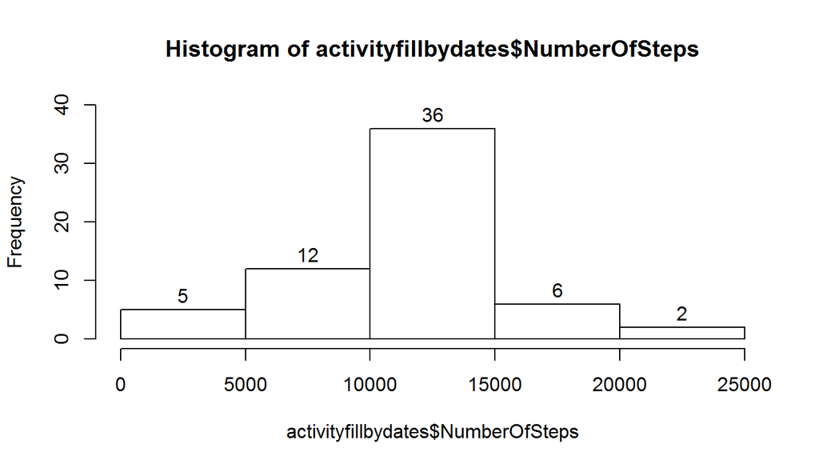

```r
activityfillbydates <- aggregate(activityfill$steps, by=list(activityfill$date), FUN=sum, na.rm=TRUE)
names(activityfillbydates) <- c("Date", "NumberOfSteps")
hist(activityfillbydates$NumberOfSteps, labels = TRUE, ylim = c(0, 40))
```

```r
meansteps <- mean(activityfillbydates$NumberOfSteps)
msg1 <- cat("Mean number of steps per day is: ", meansteps)
```

```
## Mean number of steps per day is:  10766
```

```r
mediansteps <- median(activityfillbydates$NumberOfSteps)
msg2 <- cat("Median number of steps per day is: ", mediansteps)
```

```
## Median number of steps per day is:  10766
```

**Are there differences in activity patterns between weekdays and weekends?**  
*For this part the weekdays() function may be of some help here. Use the dataset with the filled-in missing values for this part.*

1. Create a new factor variable in the dataset with two levels – “weekday” and “weekend” indicating whether a given date is a weekday or weekend day.

```r
df = data.frame(date=activityfillbydates$Date)
df$day <- weekdays(as.Date(df$date))
activityfillbydates$day <- df$day
for (i in 1:length(activityfillbydates$day)) {
    if (activityfillbydates$day[i]=="subota" || activityfillbydates$day[i]=="nedjelja"){
        activityfillbydates$day[i] <- "week_end"
        }
    else {
            activityfillbydates$day[i] <- "week_day"
        }
}
```

2. Make a panel plot containing a time series plot (i.e. type = “l”) of the 5-minute interval (x-axis) and the average number of steps taken, averaged across all weekday days or weekend days (y-axis).

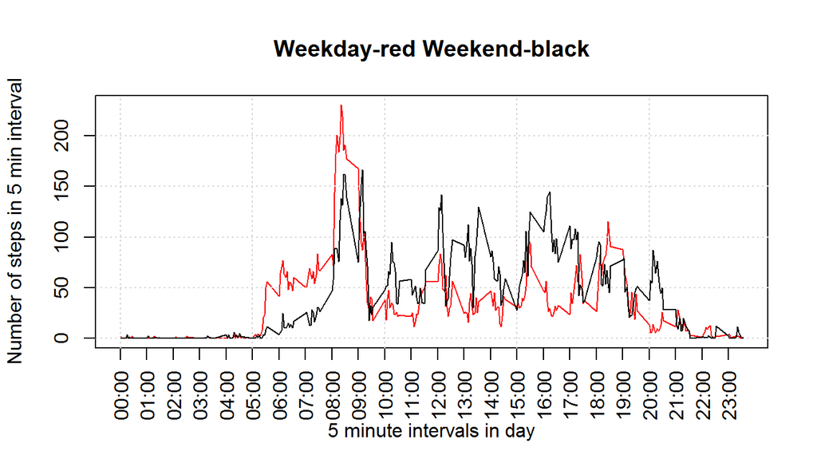

```r
for (i in 1:nrow(activityfill)) {
    activityfill$day[i] <- activityfillbydates$day[activityfillbydates$Date==activityfill$date[i] ]
}
activityfillbyintervals <- aggregate(activityfill$steps, by=list(activityfill$interval,activityfill$day), FUN=mean, na.rm=TRUE)
names(activityfillbyintervals) <- c("Interval", "Day", "NumberOfSteps")
week_days <- activityfillbyintervals[1:288,]
week_ends <- activityfillbyintervals[289:576,]
plot(week_days$Interval, week_days$NumberOfSteps, type="l", xlab = "5 minute intervals in day", ylab = "Number of steps in 5 min interval", main="Weekday-red Weekend-black", col = 'red', labels = FALSE)
axis(side=2, labels=TRUE)
axis(side=1, at=week_days$Interval[seq(1, length(week_days$Interval),12)], labels=IntervalsLabels[seq(1, length(IntervalsLabels),12)], las=2)
grid(nx = NULL, ny = NULL, col = "lightgray", lty = "dotted")
lines(week_ends$Interval, week_ends$NumberOfSteps, type="l", xlab = "5 minute intervals in day", ylab = "Number of steps in 5 min interval", labels = FALSE)
```

```r
# # axis(side=2, labels=TRUE)
# axis(side=1, at=week_ends$Interval[seq(1, length(week_ends$Interval),12)], labels=IntervalsLabels[seq(1, length(IntervalsLabels),12)], las=2)
# grid(nx = NULL, ny = NULL, col = "lightgray", lty = "dotted")
```